# ANOVA in R: The Ultimate Guide - Datanovia

[output not shown]

# Comparing Multiple Means in R

[Home](https://www.datanovia.com/en/) [Comparing Multiple Means in R](https://www.datanovia.com/en/courses/comparing-multiple-means-in-r/) ANOVA in R

## ANOVA in R

25 mins

[Comparing Multiple Means in R](https://www.datanovia.com/en/courses/comparing-multiple-means-in-r/)

The **ANOVA** test (or **Analysis of Variance**) is used to compare the mean of multiple groups. The term ANOVA is a little misleading. Although the name of the technique refers to variances, the main goal of ANOVA is to investigate differences in means.

This chapter describes the different types of ANOVA for **comparing independent groups**, including:

- **One-way ANOVA**: an extension of the independent samples t-test for comparing the means in a situation where there are more than two groups. This is the simplest case of ANOVA test where the data are organized into several groups according to only one single grouping variable (also called factor variable). Other synonyms are: *1 way ANOVA*, *one-factor ANOVA* and *between-subject ANOVA*.
- **two-way ANOVA** used to evaluate simultaneously the effect of two different grouping variables on a continuous outcome variable. Other synonyms are: *two factorial design*, *factorial anova* or *two-way between-subjects ANOVA*.
- **three-way ANOVA** used to evaluate simultaneously the effect of three different grouping variables on a continuous outcome variable. Other synonyms are: *factorial ANOVA* or *three-way between-subjects ANOVA*.

Note that, the independent grouping variables are also known as **between-subjects factors**.

The main goal of two-way and three-way ANOVA is, respectively, to evaluate if there is a statistically significant interaction effect between two and three between-subjects factors in explaining a continuous outcome variable.

You will learn how to:

- **Compute and interpret the different types of ANOVA in R** for comparing independent groups.
- **Check ANOVA test assumptions**
- **Perform post-hoc tests**, multiple pairwise comparisons between groups to identify which groups are different
- **Visualize the data** using box plots, add ANOVA and pairwise comparisons p-values to the plot

Contents:

#### [Related Book](https://www.datanovia.com/en/product/practical-statistics-in-r-for-comparing-groups-numerical-variables/)

Practical Statistics in R II - Comparing Groups: Numerical Variables

## Basics

The idea behind the ANOVA test is very simple: if the average variation between groups is large enough compared to the average variation within groups, then you could conclude that at least one group mean is not equal to the others.

Thus, it’s possible to evaluate whether the differences between the group means are significant by comparing the two variance estimates. This is why the method is called **analysis of variance** even though the main goal is to compare the group means.

Note that, a lower F value (F < 1) indicates that there are no significant difference between the means of the samples being compared.

However, a higher ratio implies that the variation among group means are greatly different from each other compared to the variation of the individual observations in each groups.

## Assumptions

The ANOVA test makes the following assumptions about the data:

- **Independence of the observations**. Each subject should belong to only one group. There is no relationship between the observations in each group. Having repeated measures for the same participants is not allowed.
- **No significant outliers** in any cell of the design
- **Normality**. the data for each design cell should be approximately normally distributed.
- **Homogeneity of variances**. The variance of the outcome variable should be equal in every cell of the design.

Before computing ANOVA test, you need to perform some preliminary tests to check if the assumptions are met.

Note that, if the above assumptions are not met there are a non-parametric alternative (*Kruskal-Wallis test*) to the one-way ANOVA.

Unfortunately, there are no non-parametric alternatives to the two-way and the three-way ANOVA. Thus, in the situation where the assumptions are not met, you could consider running the two-way/three-way ANOVA on the transformed and non-transformed data to see if there are any meaningful differences.

If both tests lead you to the same conclusions, you might not choose to transform the outcome variable and carry on with the two-way/three-way ANOVA on the original data.

It’s also possible to perform robust ANOVA test using the **WRS2** R package.

No matter your choice, you should report what you did in your results.

## Prerequisites

Make sure you have the following R packages:

- `tidyverse` for data manipulation and visualization
- `ggpubr` for creating easily publication ready plots
- `rstatix` provides pipe-friendly R functions for easy statistical analyses
- `datarium`: contains required data sets for this chapter

Load required R packages:

```r
library(tidyverse)
library(ggpubr)
library(rstatix)
```

Key R functions: `anova_test()` [rstatix package], wrapper around the function `car::Anova()`.

## One-way ANOVA

### Data preparation

Here, we’ll use the built-in R data set named `PlantGrowth`. It contains the weight of plants obtained under a control and two different treatment conditions.

Load and inspect the data by using the function `sample_n_by()` to display one random row by groups:

```r
data("PlantGrowth")
set.seed(1234)
PlantGrowth %>% sample_n_by(group, size = 1)
```

```
## # A tibble: 3 x 2
##   weight group
##    <dbl> <fct>
## 1   5.58 ctrl
## 2   6.03 trt1
## 3   4.92 trt2
```

Show the levels of the grouping variable:

```r
levels(PlantGrowth$group)
```

```
## [1] "ctrl" "trt1" "trt2"
```

If the levels are not automatically in the correct order, re-order them as follow:

```r
PlantGrowth <- PlantGrowth %>%
  reorder_levels(group, order = c("ctrl", "trt1", "trt2"))
```

The one-way ANOVA can be used to determine whether the means plant growths are significantly different between the three conditions.

### Summary statistics

Compute some summary statistics (count, mean and sd) of the variable `weight` organized by groups:

```r
PlantGrowth %>%
  group_by(group) %>%
  get_summary_stats(weight, type = "mean_sd")
```

```
## # A tibble: 3 x 5
##   group variable     n  mean    sd
##   <fct> <chr>    <dbl> <dbl> <dbl>
## 1 ctrl  weight      10  5.03 0.583
## 2 trt1  weight      10  4.66 0.794
## 3 trt2  weight      10  5.53 0.443
```

### Visualization

Create a box plot of `weight` by `group`:

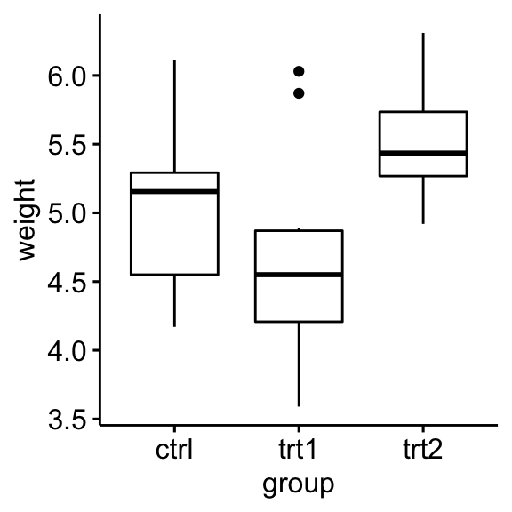

```r
ggboxplot(PlantGrowth, x = "group", y = "weight")
```

### Check assumptions

#### Outliers

Outliers can be easily identified using box plot methods, implemented in the R function `identify_outliers()` [rstatix package].

```r
PlantGrowth %>%
  group_by(group) %>%
  identify_outliers(weight)
```

```
## # A tibble: 2 x 4
##   group weight is.outlier is.extreme
##   <fct>  <dbl> <lgl>      <lgl>
## 1 trt1    5.87 TRUE       FALSE
## 2 trt1    6.03 TRUE       FALSE
```

There were no extreme outliers.

Note that, in the situation where you have extreme outliers, this can be due to: 1) data entry errors, measurement errors or unusual values.

Yo can include the outlier in the analysis anyway if you do not believe the result will be substantially affected. This can be evaluated by comparing the result of the ANOVA test with and without the outlier.

It’s also possible to keep the outliers in the data and perform robust ANOVA test using the WRS2 package.

#### Normality assumption

The normality assumption can be checked by using one of the following two approaches:

1. **Analyzing the ANOVA model residuals** to check the normality for all groups together. This approach is easier and it’s very handy when you have many groups or if there are few data points per group.
2. **Check normality for each group separately**. This approach might be used when you have only a few groups and many data points per group.

In this section, we’ll show you how to proceed for both option 1 and 2.

**Check normality assumption by analyzing the model residuals**. QQ plot and Shapiro-Wilk test of normality are used. QQ plot draws the correlation between a given data and the normal distribution.

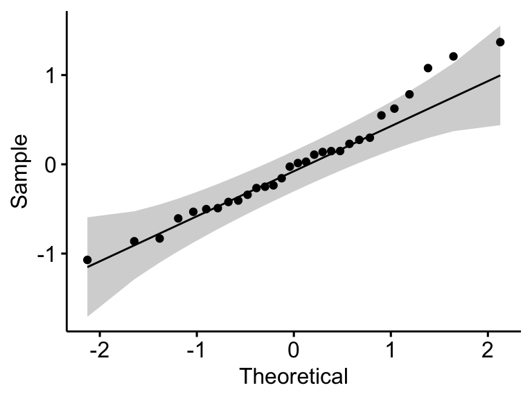

```r
# Build the linear model
model  <- lm(weight ~ group, data = PlantGrowth)
# Create a QQ plot of residuals
ggqqplot(residuals(model))
```

```r
# Compute Shapiro-Wilk test of normality
shapiro_test(residuals(model))
```

```
## # A tibble: 1 x 3
##   variable         statistic p.value
##   <chr>                <dbl>   <dbl>
## 1 residuals(model)     0.966   0.438
```

**Check normality assumption by groups**. Computing Shapiro-Wilk test for each group level. If the data is normally distributed, the p-value should be greater than 0.05.

```r
PlantGrowth %>%
  group_by(group) %>%
  shapiro_test(weight)
```

```
## # A tibble: 3 x 4
##   group variable statistic     p
##   <fct> <chr>        <dbl> <dbl>
## 1 ctrl  weight       0.957 0.747
## 2 trt1  weight       0.930 0.452
## 3 trt2  weight       0.941 0.564
```

The score were normally distributed (p > 0.05) for each group, as assessed by Shapiro-Wilk’s test of normality.

Note that, if your sample size is greater than 50, the normal QQ plot is preferred because at larger sample sizes the Shapiro-Wilk test becomes very sensitive even to a minor deviation from normality.

QQ plot draws the correlation between a given data and the normal distribution. Create QQ plots for each group level:

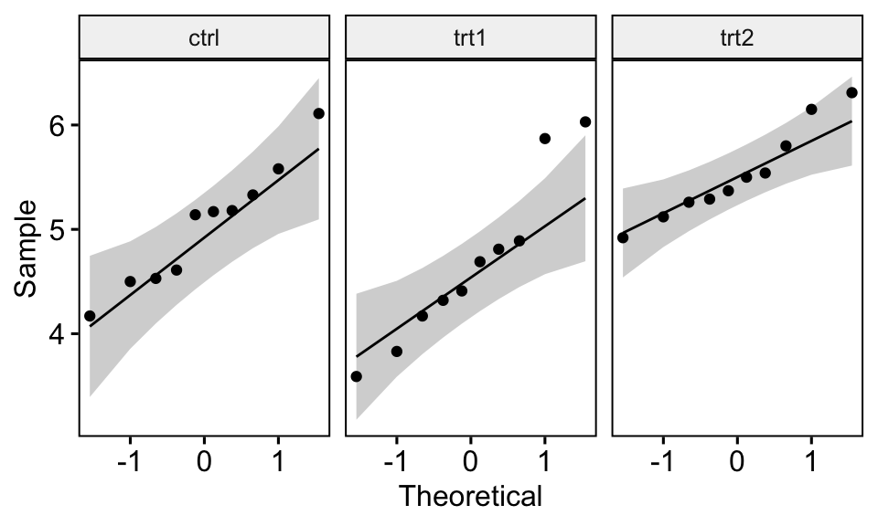

```r
ggqqplot(PlantGrowth, "weight", facet.by = "group")
```

All the points fall approximately along the reference line, for each cell. So we can assume normality of the data.

If you have doubt about the normality of the data, you can use the *Kruskal-Wallis test*, which is the non-parametric alternative to one-way ANOVA test.

#### Homogneity of variance assumption

1. The *residuals versus fits plot* can be used to check the homogeneity of variances.

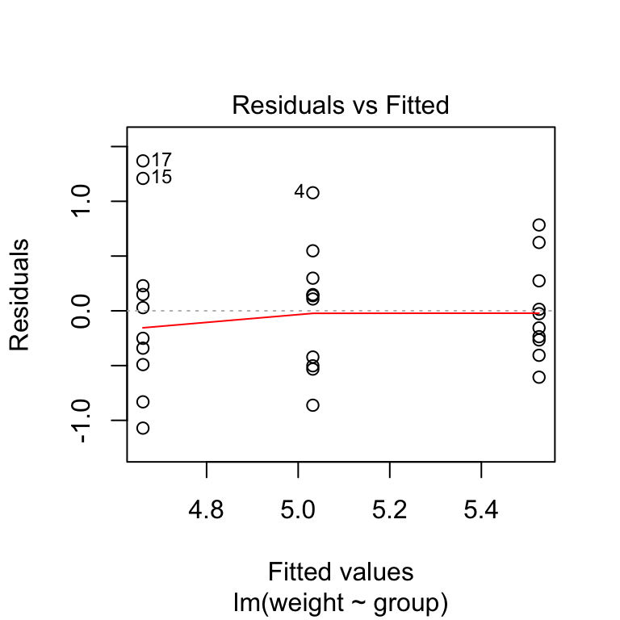

```r
plot(model, 1)
```

In the plot above, there is no evident relationships between residuals and fitted values (the mean of each groups), which is good. So, we can assume the homogeneity of variances.

2. It’s also possible to use the *Levene’s test* to check the *homogeneity of variances*:

```r
PlantGrowth %>% levene_test(weight ~ group)
```

```
## # A tibble: 1 x 4
##     df1   df2 statistic     p
##   <int> <int>     <dbl> <dbl>
## 1     2    27      1.12 0.341
```

From the output above, we can see that the p-value is > 0.05, which is not significant. This means that, there is not significant difference between variances across groups. Therefore, we can assume the homogeneity of variances in the different treatment groups.

In a situation where the homogeneity of variance assumption is not met, you can compute the Welch one-way ANOVA test using the function *welch_anova_test()*[rstatix package]. This test does not require the assumption of equal variances.

### Computation

```r
res.aov <- PlantGrowth %>% anova_test(weight ~ group)
res.aov
```

```
## ANOVA Table (type II tests)
##
##   Effect DFn DFd    F     p p<.05   ges
## 1  group   2  27 4.85 0.016     * 0.264
```

In the table above, the column `ges` corresponds to the generalized eta squared (effect size). It measures the proportion of the variability in the outcome variable (here plant `weight`) that can be explained in terms of the predictor (here, treatment `group`). An effect size of 0.26 (26%) means that 26% of the change in the `weight` can be accounted for the treatment conditions.

where,

- `F` indicates that we are comparing to an F-distribution (F-test); `(2, 27)` indicates the degrees of freedom in the numerator (DFn) and the denominator (DFd), respectively; `4.85` indicates the obtained F-statistic value
- `p` specifies the p-value
- `ges` is the generalized effect size (amount of variability due to the factor)

### Post-hoc tests

A significant one-way ANOVA is generally followed up by Tukey post-hoc tests to perform multiple pairwise comparisons between groups. Key R function: `tukey_hsd()` [rstatix].

```r
# Pairwise comparisons
pwc <- PlantGrowth %>% tukey_hsd(weight ~ group)
pwc
```

```
## # A tibble: 3 x 8
##   term  group1 group2 estimate conf.low conf.high p.adj p.adj.signif
## * <chr> <chr>  <chr>     <dbl>    <dbl>     <dbl> <dbl> <chr>
## 1 group ctrl   trt1     -0.371   -1.06      0.320 0.391 ns
## 2 group ctrl   trt2      0.494   -0.197     1.19  0.198 ns
## 3 group trt1   trt2      0.865    0.174     1.56  0.012 *
```

The output contains the following columns:

- `estimate`: estimate of the difference between means of the two groups
- `conf.low`, `conf.high`: the lower and the upper end point of the confidence interval at 95% (default)
- `p.adj`: p-value after adjustment for the multiple comparisons.

It can be seen from the output, that only the difference between trt2 and trt1 is significant (adjusted p-value = 0.012).

### Report

We could report the results of one-way ANOVA as follow:

A one-way ANOVA was performed to evaluate if the plant growth was different for the 3 different treatment groups: ctr (n = 10), trt1 (n = 10) and trt2 (n = 10).

Data is presented as mean +/- standard deviation. Plant growth was statistically significantly different between different treatment groups, F(2, 27) = 4.85, p = 0.016, generalized eta squared = 0.26.

Plant growth decreased in trt1 group (4.66 +/- 0.79) compared to ctr group (5.03 +/- 0.58). It increased in trt2 group (5.53 +/- 0.44) compared to trt1 and ctr group.

Tukey post-hoc analyses revealed that the increase from trt1 to trt2 (0.87, 95% CI (0.17 to 1.56)) was statistically significant (p = 0.012), but no other group differences were statistically significant.

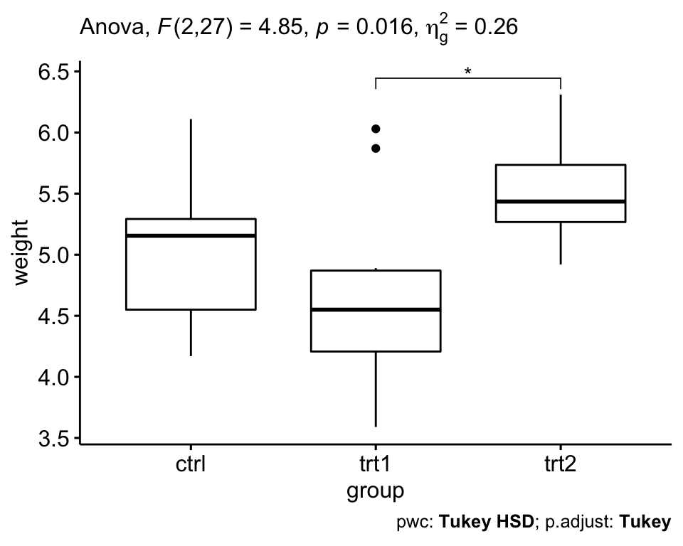

```r
# Visualization: box plots with p-values
pwc <- pwc %>% add_xy_position(x = "group")
ggboxplot(PlantGrowth, x = "group", y = "weight") +
  stat_pvalue_manual(pwc, hide.ns = TRUE) +
  labs(
    subtitle = get_test_label(res.aov, detailed = TRUE),
    caption = get_pwc_label(pwc)
    )
```

### Relaxing the homogeneity of variance assumption

The classical one-way ANOVA test requires an assumption of equal variances for all groups. In our example, the homogeneity of variance assumption turned out to be fine: the Levene test is not significant.

How do we save our ANOVA test, in a situation where the homogeneity of variance assumption is violated?

- The **Welch one-way test** is an alternative to the standard one-way ANOVA in the situation where the homogeneity of variance can’t be assumed (i.e., *Levene test* is significant).
- In this case, the **Games-Howell** post hoc test or **pairwise t-tests** (with no assumption of equal variances) can be used to compare all possible combinations of group differences.

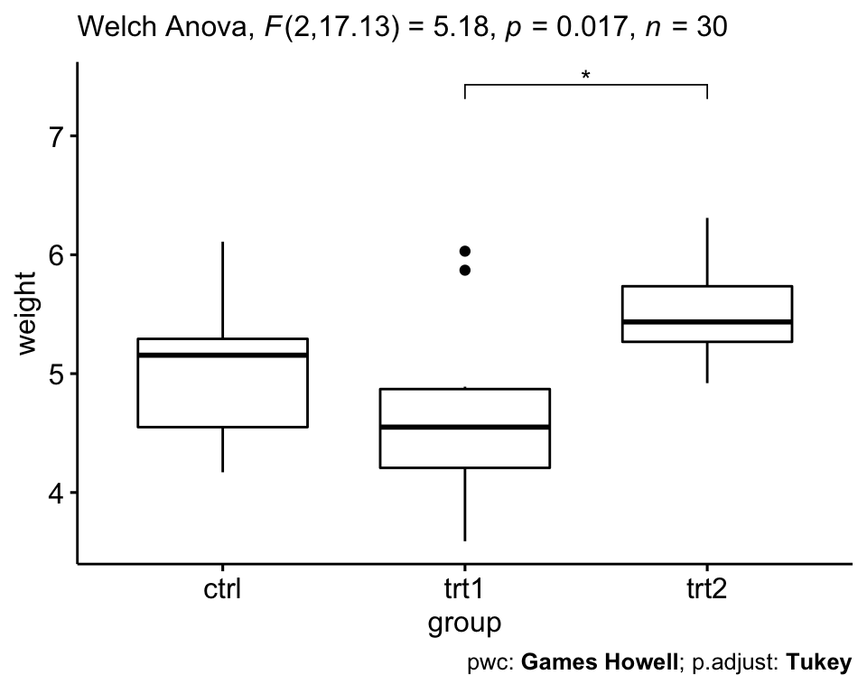

```r
# Welch One way ANOVA test
res.aov2 <- PlantGrowth %>% welch_anova_test(weight ~ group)
# Pairwise comparisons (Games-Howell)
pwc2 <- PlantGrowth %>% games_howell_test(weight ~ group)
# Visualization: box plots with p-values
pwc2 <- pwc2 %>% add_xy_position(x = "group", step.increase = 1)
ggboxplot(PlantGrowth, x = "group", y = "weight") +
  stat_pvalue_manual(pwc2, hide.ns = TRUE) +
  labs(
    subtitle = get_test_label(res.aov2, detailed = TRUE),
    caption = get_pwc_label(pwc2)
    )
```

You can also perform pairwise comparisons using pairwise t-test with no assumption of equal variances:

```r
pwc3 <- PlantGrowth %>%
  pairwise_t_test(
    weight ~ group, pool.sd = FALSE,
    p.adjust.method = "bonferroni"
    )
pwc3
```

## Two-way ANOVA

### Data preparation

We’ll use the `jobsatisfaction` dataset [datarium package], which contains the job satisfaction score organized by gender and education levels.

In this study, a research wants to evaluate if there is a significant two-way interaction between `gender` and `education_level` on explaining the job satisfaction score. An interaction effect occurs when the effect of one independent variable on an outcome variable depends on the level of the other independent variables. If an interaction effect does not exist, main effects could be reported.

Load the data and inspect one random row by groups:

```r
set.seed(123)
data("jobsatisfaction", package = "datarium")
jobsatisfaction %>% sample_n_by(gender, education_level, size = 1)
```

```
## # A tibble: 6 x 4
##   id    gender education_level score
##   <fct> <fct>  <fct>           <dbl>
## 1 3     male   school           5.07
## 2 17    male   college          6.3
## 3 23    male   university      10
## 4 37    female school           5.51
## 5 48    female college          5.65
## 6 49    female university       8.26
```

In this example, the effect of “education_level” is our **focal variable**, that is our primary concern. It is thought that the effect of “education_level” will depend on one other factor, “gender”, which are called a **moderator variable**.

### Summary statistics

Compute the mean and the SD (standard deviation) of the `score` by groups:

```r
jobsatisfaction %>%
  group_by(gender, education_level) %>%
  get_summary_stats(score, type = "mean_sd")
```

```
## # A tibble: 6 x 6
##   gender education_level variable     n  mean    sd
##   <fct>  <fct>           <chr>    <dbl> <dbl> <dbl>
## 1 male   school          score        9  5.43 0.364
## 2 male   college         score        9  6.22 0.34
## 3 male   university      score       10  9.29 0.445
## 4 female school          score       10  5.74 0.474
## 5 female college         score       10  6.46 0.475
## 6 female university      score       10  8.41 0.938
```

### Visualization

Create a box plot of the score by gender levels, colored by education levels:

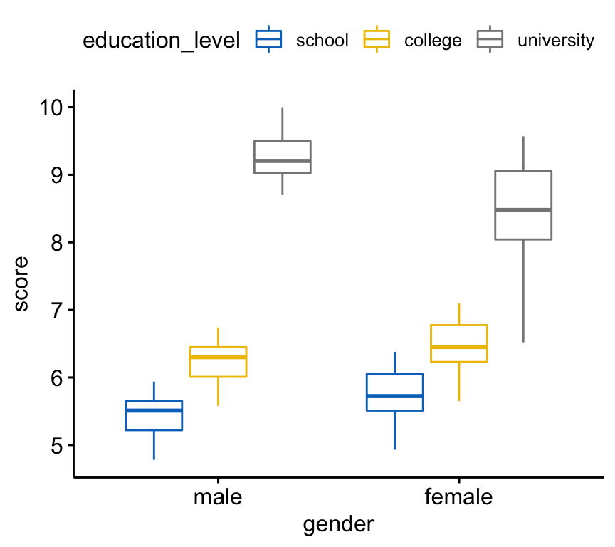

```r
bxp <- ggboxplot(
  jobsatisfaction, x = "gender", y = "score",
  color = "education_level", palette = "jco"
  )
bxp
```

### Check assumptions

#### Outliers

Identify outliers in each cell design:

```r
jobsatisfaction %>%
  group_by(gender, education_level) %>%
  identify_outliers(score)
```

[output not shown]

There were no extreme outliers.

#### Normality assumption

**Check normality assumption by analyzing the model residuals**. QQ plot and Shapiro-Wilk test of normality are used.

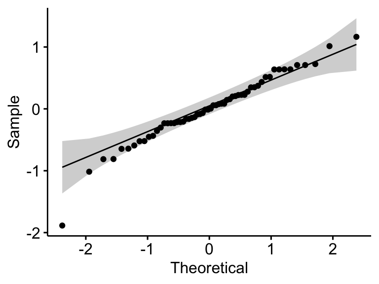

```r
# Build the linear model
model  <- lm(score ~ gender*education_level,
             data = jobsatisfaction)
# Create a QQ plot of residuals
ggqqplot(residuals(model))
```

```r
# Compute Shapiro-Wilk test of normality
shapiro_test(residuals(model))
```

```
## # A tibble: 1 x 3
##   variable         statistic p.value
##   <chr>                <dbl>   <dbl>
## 1 residuals(model)     0.968   0.127
```

In the QQ plot, as all the points fall approximately along the reference line, we can assume normality. This conclusion is supported by the Shapiro-Wilk test. The p-value is not significant (p = 0.13), so we can assume normality.

**Check normality assumption by groups**. Computing Shapiro-Wilk test for each combinations of factor levels:

```r
jobsatisfaction %>%
  group_by(gender, education_level) %>%
  shapiro_test(score)
```

```
## # A tibble: 6 x 5
##   gender education_level variable statistic     p
##   <fct>  <fct>           <chr>        <dbl> <dbl>
## 1 male   school          score        0.980 0.966
## 2 male   college         score        0.958 0.779
## 3 male   university      score        0.916 0.323
## 4 female school          score        0.963 0.819
## 5 female college         score        0.963 0.819
## 6 female university      score        0.950 0.674
```

The score were normally distributed (p > 0.05) for each cell, as assessed by Shapiro-Wilk’s test of normality.

Create QQ plots for each cell of design:

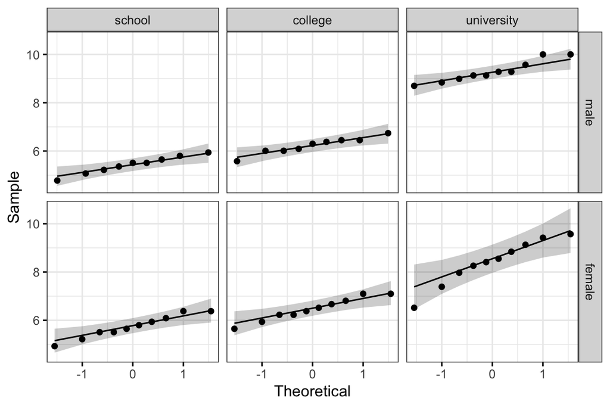

```r
ggqqplot(jobsatisfaction, "score", ggtheme = theme_bw()) +
  facet_grid(gender ~ education_level)
```

All the points fall approximately along the reference line, for each cell. So we can assume normality of the data.

#### Homogneity of variance assumption

This can be checked using the Levene’s test:

```r
jobsatisfaction %>% levene_test(score ~ gender*education_level)
```

```
## # A tibble: 1 x 4
##     df1   df2 statistic      p
##   <int> <int>     <dbl>  <dbl>
## 1     5    52      2.20 0.0686
```

The Levene’s test is not significant (p > 0.05). Therefore, we can assume the homogeneity of variances in the different groups.

### Computation

In the R code below, the asterisk represents the interaction effect and the main effect of each variable (and all lower-order interactions).

```r
res.aov <- jobsatisfaction %>% anova_test(score ~ gender * education_level)
res.aov
```

```
## ANOVA Table (type II tests)
##
##                   Effect DFn DFd       F        p p<.05   ges
## 1                 gender   1  52   0.745 3.92e-01       0.014
## 2        education_level   2  52 187.892 1.60e-24     * 0.878
## 3 gender:education_level   2  52   7.338 2.00e-03     * 0.220
```

There was a statistically significant interaction between gender and level of education for job satisfaction score, *F(2, 52) = 7.34, p = 0.002*.

### Post-hoct tests

A **significant two-way interaction** indicates that the impact that one factor (e.g., education_level) has on the outcome variable (e.g., job satisfaction score) depends on the level of the other factor (e.g., gender) (and vice versa). So, you can decompose a significant two-way interaction into:

- **Simple main effect**: run one-way model of the first variable at each level of the second variable,
- **Simple pairwise comparisons**: if the simple main effect is significant, run multiple pairwise comparisons to determine which groups are different.

For a **non-significant two-way interaction**, you need to determine whether you have any statistically significant **main effects** from the ANOVA output. A significant main effect can be followed up by pairwise comparisons between groups.

#### Procedure for significant two-way interaction

##### Compute simple main effects

In our example, you could therefore investigate the effect of `education_level` at every level of `gender` or investigate the effect of `gender` at every level of the variable `education_level`.

Here, we’ll run a one-way ANOVA of `education_level` at each levels of `gender`.

Note that, if you have met the assumptions of the two-way ANOVA (e.g., homogeneity of variances), it is better to use the overall error term (from the two-way ANOVA) as input in the one-way ANOVA model. This will make it easier to detect any statistically significant differences if they exist (Keppel & Wickens, 2004; Maxwell & Delaney, 2004).

When you have failed the homogeneity of variances assumptions, you might consider running separate one-way ANOVAs with separate error terms.

In the R code below, we’ll group the data by gender and analyze the **simple main effects** of education level on Job Satisfaction score. The argument `error` is used to specify the ANOVA model from which the pooled error sum of squares and degrees of freedom are to be calculated.

```r
# Group the data by gender and fit  anova
model <- lm(score ~ gender * education_level, data = jobsatisfaction)
jobsatisfaction %>%
  group_by(gender) %>%
  anova_test(score ~ education_level, error = model)
```

```
## # A tibble: 2 x 8
##   gender Effect            DFn   DFd     F        p `p<.05`   ges
##   <fct>  <chr>           <dbl> <dbl> <dbl>    <dbl> <chr>   <dbl>
## 1 male   education_level     2    52 132.  3.92e-21 *       0.836
## 2 female education_level     2    52  62.8 1.35e-14 *       0.707
```

The simple main effect of “education_level” on job satisfaction score was statistically significant for both male and female (p < 0.0001).

In other words, there is a statistically significant difference in mean job satisfaction score between **males** educated to either school, college or university level, F(2, 52) = 132, p < 0.0001. The same conclusion holds true for **females**, F(2, 52) = 62.8, p < 0.0001.

Note that, statistical significance of the simple main effect analyses was accepted at a Bonferroni-adjusted alpha level of 0.025. This corresponds to the current level you declare statistical significance at (i.e., p < 0.05) divided by the number of simple main effect you are computing (i.e., 2).

##### Compute pairwise comparisons

A statistically significant simple main effect can be followed up by **multiple pairwise comparisons** to determine which group means are different. We’ll now perform multiple pairwise comparisons between the different `education_level` groups by `gender`.

You can run and interpret all possible pairwise comparisons using a Bonferroni adjustment. This can be easily done using the function `emmeans_test()` [rstatix package], a wrapper around the `emmeans` package, which needs to be installed. Emmeans stands for **estimated marginal means** (aka least square means or adjusted means).

**Compare the score of the different education levels** by `gender` levels:

```r
# pairwise comparisons
library(emmeans)
pwc <- jobsatisfaction %>%
  group_by(gender) %>%
  emmeans_test(score ~ education_level, p.adjust.method = "bonferroni")
pwc
```

```
## # A tibble: 6 x 9
##   gender .y.   group1  group2        df statistic        p    p.adj p.adj.signif
## * <fct>  <chr> <chr>   <chr>      <dbl>     <dbl>    <dbl>    <dbl> <chr>
## 1 male   score school  college       52     -3.07 3.37e- 3 1.01e- 2 *
## 2 male   score school  university    52    -15.3  6.87e-21 2.06e-20 ****
## 3 male   score college university    52    -12.1  8.42e-17 2.53e-16 ****
## 4 female score school  college       52     -2.94 4.95e- 3 1.49e- 2 *
## 5 female score school  university    52    -10.8  6.07e-15 1.82e-14 ****
## 6 female score college university    52     -7.90 1.84e-10 5.52e-10 ****
```

There was a significant difference of job satisfaction score between all groups for both males and females (p < 0.05).

#### Procedure for non-significant two-way interaction

##### Inspect main effects

If the two-way interaction is not statistically significant, you need to consult the main effect for each of the two variables (gender and education_level) in the ANOVA output.

```r
res.aov
```

```
## ANOVA Table (type II tests)
##
##                   Effect DFn DFd       F        p p<.05   ges
## 1                 gender   1  52   0.745 3.92e-01       0.014
## 2        education_level   2  52 187.892 1.60e-24     * 0.878
## 3 gender:education_level   2  52   7.338 2.00e-03     * 0.220
```

In our example, there was a statistically significant main effects of education_level (F(2, 52) = 187.89, p < 0.0001) on the job satisfaction score. However, the main effect of gender was not significant, F (1, 52) = 0.74, p = 0.39.

##### Compute pairwise comparisons

Perform pairwise comparisons between education level groups to determine which groups are significantly different. Bonferroni adjustment is applied. This analysis can be done using simply the R base function `pairwise_t_test()` or using the function `emmeans_test()`.

- Pairwise t-test:

```r
jobsatisfaction %>%
  pairwise_t_test(
    score ~ education_level,
    p.adjust.method = "bonferroni"
    )
```

[output not shown]

All pairwise differences were statistically significant (p < 0.05).

- Pairwise comparisons using Emmeans test. You need to specify the overall model, from which the overall degrees of freedom are to be calculated. This will make it easier to detect any statistically significant differences if they exist.

```r
model <- lm(score ~ gender * education_level, data = jobsatisfaction)
jobsatisfaction %>%
  emmeans_test(
    score ~ education_level, p.adjust.method = "bonferroni",
    model = model
    )
```

### Report

A two-way ANOVA was conducted to examine the effects of gender and education level on job satisfaction score.

Residual analysis was performed to test for the assumptions of the two-way ANOVA. Outliers were assessed by box plot method, normality was assessed using Shapiro-Wilk’s normality test and homogeneity of variances was assessed by Levene’s test.

There were no extreme outliers, residuals were normally distributed (p > 0.05) and there was homogeneity of variances (p > 0.05).

There was a statistically significant interaction between gender and education level on job satisfaction score, `F(2, 52) = 7.33, p = 0.0016, eta2[g] = 0.22`.

Consequently, an analysis of simple main effects for education level was performed with statistical significance receiving a Bonferroni adjustment. There was a statistically significant difference in mean “job satisfaction” scores for both males (`F(2, 52) = 132, p < 0.0001`) and females (`F(2, 52) = 62.8, p < 0.0001`) educated to either school, college or university level.

All pairwise comparisons were analyzed between the different `education_level` groups organized by `gender`. There was a significant difference of Job Satisfaction score between all groups for both males and females (p < 0.05).

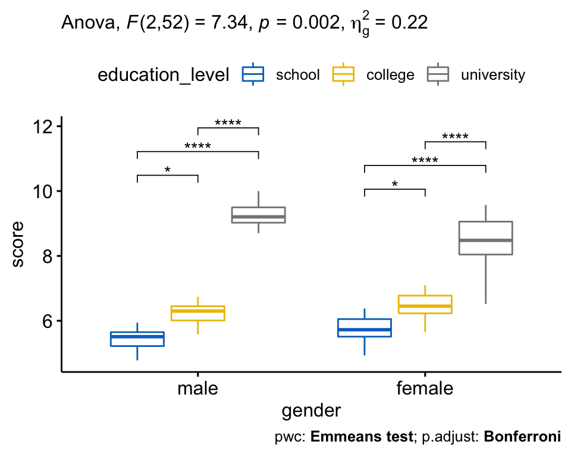

```r
# Visualization: box plots with p-values
pwc <- pwc %>% add_xy_position(x = "gender")
bxp +
  stat_pvalue_manual(pwc) +
  labs(
    subtitle = get_test_label(res.aov, detailed = TRUE),
    caption = get_pwc_label(pwc)
    )
```

## Three-Way ANOVA

The **three-way ANOVA** is an extension of the two-way ANOVA for assessing whether there is an interaction effect between three independent categorical variables on a continuous outcome variable.

### Data preparation

We’ll use the `headache` dataset [datarium package], which contains the measures of migraine headache episode pain score in 72 participants treated with three different treatments. The participants include 36 males and 36 females. Males and females were further subdivided into whether they were at low or high risk of migraine.

We want to understand how each independent variable (type of treatments, risk of migraine and gender) interact to predict the pain score.

Load the data and inspect one random row by group combinations:

```r
set.seed(123)
data("headache", package = "datarium")
headache %>% sample_n_by(gender, risk, treatment, size = 1)
```

```
## # A tibble: 12 x 5
##      id gender risk  treatment pain_score
##   <int> <fct>  <fct> <fct>          <dbl>
## 1    20 male   high  X              100
## 2    29 male   high  Y               91.2
## 3    33 male   high  Z               81.3
## 4     6 male   low   X               73.1
## 5    12 male   low   Y               67.9
## 6    13 male   low   Z               75.0
## # … with 6 more rows
```

In this example, the effect of the treatment types is our **focal variable**, that is our primary concern. It is thought that the effect of treatments will depend on two other factors, “gender” and “risk” level of migraine, which are called **moderator variables**.

### Summary statistics

Compute the mean and the standard deviation (SD) of `pain_score` by groups:

```r
headache %>%
  group_by(gender, risk, treatment) %>%
  get_summary_stats(pain_score, type = "mean_sd")
```

```
## # A tibble: 12 x 7
##   gender risk  treatment variable       n  mean    sd
##   <fct>  <fct> <fct>     <chr>      <dbl> <dbl> <dbl>
## 1 male   high  X         pain_score     6  92.7  5.12
## 2 male   high  Y         pain_score     6  82.3  5.00
## 3 male   high  Z         pain_score     6  79.7  4.05
## 4 male   low   X         pain_score     6  76.1  3.86
## 5 male   low   Y         pain_score     6  73.1  4.76
## 6 male   low   Z         pain_score     6  74.5  4.89
## # … with 6 more rows
```

### Visualization

Create a box plot of `pain_score` by `treatment`, color lines by risk groups and facet the plot by gender:

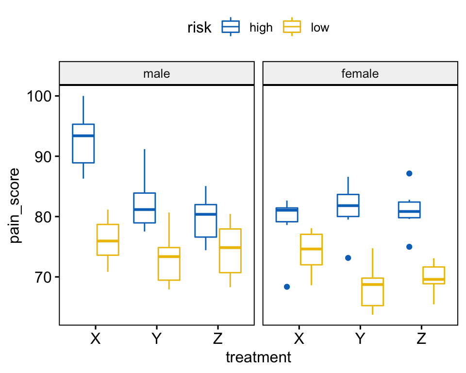

```r
bxp <- ggboxplot(
  headache, x = "treatment", y = "pain_score",
  color = "risk", palette = "jco", facet.by = "gender"
  )
bxp
```

### Check assumptions

#### Outliers

Identify outliers by groups:

```r
headache %>%
  group_by(gender, risk, treatment) %>%
  identify_outliers(pain_score)
```

```
## # A tibble: 4 x 7
##   gender risk  treatment    id pain_score is.outlier is.extreme
##   <fct>  <fct> <fct>     <int>      <dbl> <lgl>      <lgl>
## 1 female high  X            57       68.4 TRUE       TRUE
## 2 female high  Y            62       73.1 TRUE       FALSE
## 3 female high  Z            67       75.0 TRUE       FALSE
## 4 female high  Z            71       87.1 TRUE       FALSE
```

It can be seen that, the data contain one extreme outlier (id = 57, female at high risk of migraine taking drug X)

Outliers can be due to: 1) data entry errors, 2) measurement errors or 3) unusual values.

Yo can include the outlier in the analysis anyway if you do not believe the result will be substantially affected. This can be evaluated by comparing the result of the ANOVA test with and without the outlier.

It’s also possible to keep the outliers in the data and perform robust ANOVA test using the WRS2 package.

#### Normality assumption

**Check normality assumption by analyzing the model residuals**. QQ plot and Shapiro-Wilk test of normality are used.

```
## # A tibble: 1 x 3
##   variable         statistic p.value
##   <chr>                <dbl>   <dbl>
## 1 residuals(model)     0.982   0.398
```

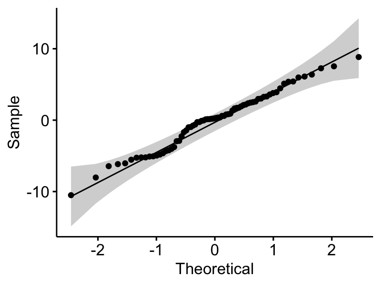

```r
model  <- lm(pain_score ~ gender*risk*treatment, data = headache)
# Create a QQ plot of residuals
ggqqplot(residuals(model))
# Compute Shapiro-Wilk test of normality
shapiro_test(residuals(model))
```

In the QQ plot, as all the points fall approximately along the reference line, we can assume normality. This conclusion is supported by the Shapiro-Wilk test. The p-value is not significant (p = 0.4), so we can assume normality.

**Check normality assumption by groups**. Computing Shapiro-Wilk test for each combinations of factor levels.

```r
headache %>%
  group_by(gender, risk, treatment) %>%
  shapiro_test(pain_score)
```

```
## # A tibble: 12 x 6
##   gender risk  treatment variable   statistic     p
##   <fct>  <fct> <fct>     <chr>          <dbl> <dbl>
## 1 male   high  X         pain_score     0.958 0.808
## 2 male   high  Y         pain_score     0.902 0.384
## 3 male   high  Z         pain_score     0.955 0.784
## 4 male   low   X         pain_score     0.982 0.962
## 5 male   low   Y         pain_score     0.920 0.507
## 6 male   low   Z         pain_score     0.924 0.535
## # … with 6 more rows
```

The pain scores were normally distributed (p > 0.05) except for one group (female at high risk of migraine taking drug X, p = 0.0086), as assessed by Shapiro-Wilk’s test of normality.

Create QQ plot for each cell of design:

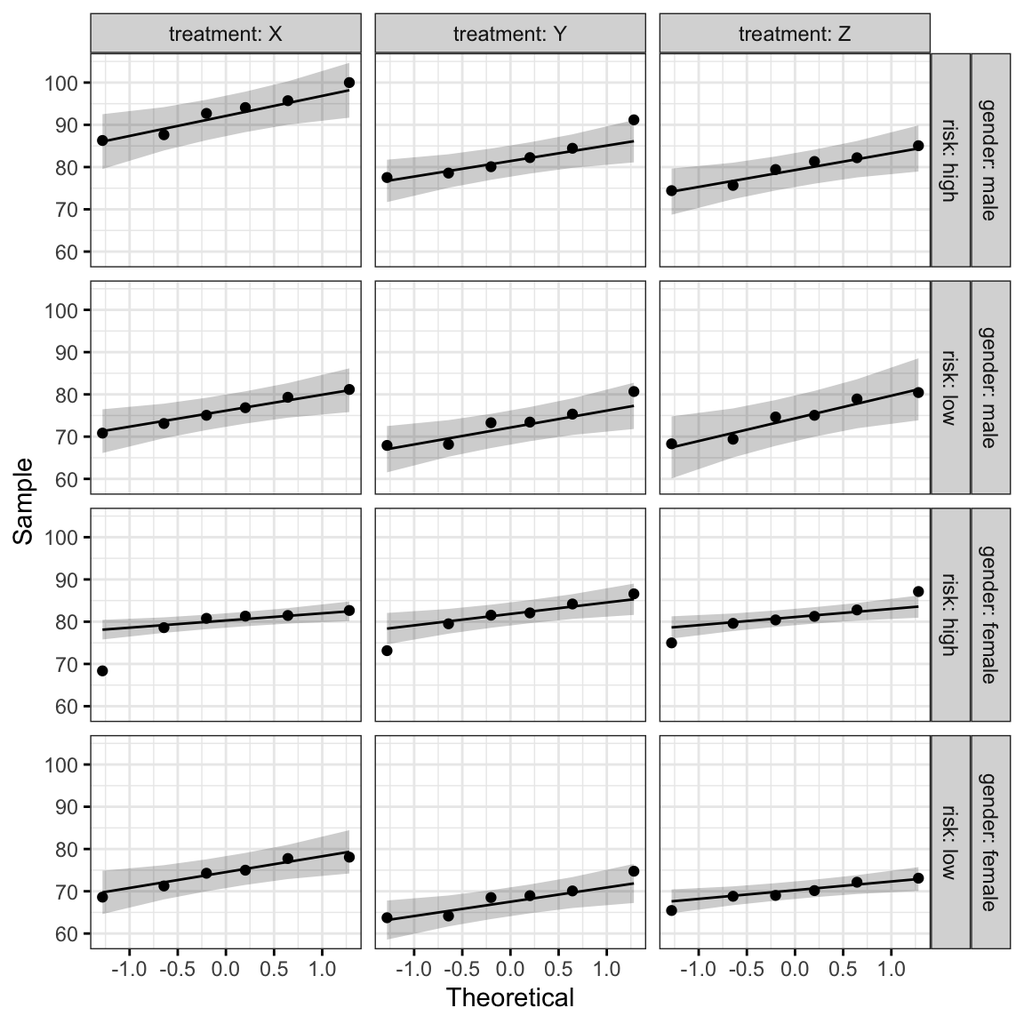

```r
ggqqplot(headache, "pain_score", ggtheme = theme_bw()) +
  facet_grid(gender + risk ~ treatment, labeller = "label_both")
```

All the points fall approximately along the reference line, except for one group (female at high risk of migraine taking drug X), where we already identified an extreme outlier.

#### Homogneity of variance assumption

This can be checked using the Levene’s test:

```r
headache %>% levene_test(pain_score ~ gender*risk*treatment)
```

```
## # A tibble: 1 x 4
##     df1   df2 statistic     p
##   <int> <int>     <dbl> <dbl>
## 1    11    60     0.179 0.998
```

The Levene’s test is not significant (p > 0.05). Therefore, we can assume the homogeneity of variances in the different groups.

### Computation

```r
res.aov <- headache %>% anova_test(pain_score ~ gender*risk*treatment)
res.aov
```

```
## ANOVA Table (type II tests)
##
##                  Effect DFn DFd      F        p p<.05   ges
## 1                gender   1  60 16.196 1.63e-04     * 0.213
## 2                  risk   1  60 92.699 8.80e-14     * 0.607
## 3             treatment   2  60  7.318 1.00e-03     * 0.196
## 4           gender:risk   1  60  0.141 7.08e-01       0.002
## 5      gender:treatment   2  60  3.338 4.20e-02     * 0.100
## 6        risk:treatment   2  60  0.713 4.94e-01       0.023
## 7 gender:risk:treatment   2  60  7.406 1.00e-03     * 0.198
```

There was a statistically significant three-way interaction between gender, risk and treatment, *F(2, 60) = 7.41, p = 0.001*.

### Post-hoc tests

**If there is a significant three-way interaction effect**, you can decompose it into:

- **Simple two-way interaction**: run two-way interaction at each level of third variable,
- **Simple simple main effect**: run one-way model at each level of second variable, and
- **simple simple pairwise comparisons**: run pairwise or other post-hoc comparisons if necessary.

**If you do not have a statistically significant three-way interaction**, you need to determine whether you have any statistically significant two-way interaction from the ANOVA output. You can follow up a significant two-way interaction by simple main effects analyses and pairwise comparisons between groups if necessary.

In this section we’ll describe the procedure for a significant three-way interaction.

#### Compute simple two-way interactions

You are free to decide which two variables will form the simple two-way interactions and which variable will act as the third (moderator) variable. In our example, we want to evaluate the effect of `risk*treatment` interaction on `pain_score` at each level of gender.

Note that, when doing the two-way interaction analysis, it’s better to use the overall error term (or residuals) from the three-way ANOVA result, obtained previously using the whole dataset. This is particularly recommended when the homogeneity of variance assumption is met (Keppel & Wickens, 2004).

The use of group-specific error term is “safer” from any violations of the assumptions. However, the pooled error terms have greater power – particularly with small sample sizes – but are susceptible to problems if there are any violations of assumptions.

In the R code below, we’ll group the data by gender and fit the `treatment*risk` two-way interaction. The argument `error` is used to specify the three-way ANOVA model from which the pooled error sum of squares and degrees of freedom are to be calculated.

```r
# Group the data by gender and
# fit simple two-way interaction
model  <- lm(pain_score ~ gender*risk*treatment, data = headache)
headache %>%
  group_by(gender) %>%
  anova_test(pain_score ~ risk*treatment, error = model)
```

```
## # A tibble: 6 x 8
##   gender Effect           DFn   DFd      F             p `p<.05`   ges
##   <fct>  <chr>          <dbl> <dbl>  <dbl>         <dbl> <chr>   <dbl>
## 1 male   risk               1    60 50.0   0.00000000187 *       0.455
## 2 male   treatment          2    60 10.2   0.000157      *       0.253
## 3 male   risk:treatment     2    60  5.25  0.008         *       0.149
## 4 female risk               1    60 42.8   0.0000000150  *       0.416
## 5 female treatment          2    60  0.482 0.62          ""      0.016
## 6 female risk:treatment     2    60  2.87  0.065         ""      0.087
```

There was a statistically significant simple two-way interaction between risk and treatment (**risk:treatment**) for males, F(2, 60) = 5.25, p = 0.008, but not for females, F(2, 60) = 2.87, p = 0.065.

For males, this result suggests that the effect of treatment on “pain_score” depends on one’s “risk” of migraine. In other words, the risk moderates the effect of the type of treatment on pain_score.

Note that, statistical significance of a simple two-way interaction was accepted at a Bonferroni-adjusted alpha level of 0.025. This corresponds to the current level you declare statistical significance at (i.e., p < 0.05) divided by the number of simple two-way interaction you are computing (i.e., 2).

#### Compute simple simple main effects

A statistically significant simple two-way interaction can be followed up with **simple simple main effects**. In our example, you could therefore investigate the effect of `treatment` on `pain_score` at every level of `risk` or investigate the effect of `risk` at every level of `treatment`.

You will only need to do this for the simple two-way interaction for “males” as this was the only simple two-way interaction that was statistically significant. The error term again comes from the three-way ANOVA.

Group the data by `gender` and `risk` and analyze the **simple simple main effects** of treatment on pain_score:

```r
# Group the data by gender and risk, and fit  anova
treatment.effect <- headache %>%
  group_by(gender, risk) %>%
  anova_test(pain_score ~ treatment, error = model)
treatment.effect %>% filter(gender == "male")
```

```
## # A tibble: 2 x 9
##   gender risk  Effect      DFn   DFd     F         p `p<.05`   ges
##   <fct>  <fct> <chr>     <dbl> <dbl> <dbl>     <dbl> <chr>   <dbl>
## 1 male   high  treatment     2    60 14.8  0.0000061 *       0.33
## 2 male   low   treatment     2    60  0.66 0.521     ""      0.022
```

In the table above, we only need the results for the simple simple main effects of treatment for: (1) “males” at “low” risk; and (2) “males” at “high” risk.

Statistical significance was accepted at a Bonferroni-adjusted alpha level of 0.025, that is 0.05 divided y the number of simple simple main effects you are computing (i.e., 2).

There was a statistically significant simple simple main effect of treatment for males at high risk of migraine, F(2, 60) = 14.8, p < 0.0001), but not for males at low risk of migraine, F(2, 60) = 0.66, p = 0.521.

This analysis indicates that, the type of treatment taken has a statistically significant effect on pain_score in males who are at high risk.

In other words, the mean pain_score in the treatment X, Y and Z groups was statistically significantly different for males who at high risk, but not for males at low risk.

#### Compute simple simple comparisons

A statistically significant simple simple main effect can be followed up by **multiple pairwise comparisons** to determine which group means are different. This can be easily done using the function `emmeans_test()` [rstatix package] described in the previous section.

**Compare the different treatments** by `gender` and `risk` variables:

```r
# Pairwise comparisons
library(emmeans)
pwc <- headache %>%
  group_by(gender, risk) %>%
  emmeans_test(pain_score ~ treatment, p.adjust.method = "bonferroni") %>%
  select(-df, -statistic, -p) # Remove details
# Show comparison results for male at high risk
pwc %>% filter(gender == "male", risk == "high")
```

```
## # A tibble: 3 x 7
##   gender risk  .y.        group1 group2      p.adj p.adj.signif
##   <fct>  <fct> <chr>      <chr>  <chr>       <dbl> <chr>
## 1 male   high  pain_score X      Y      0.000386   ***
## 2 male   high  pain_score X      Z      0.00000942 ****
## 3 male   high  pain_score Y      Z      0.897      ns
```

```r
# Estimated marginal means (i.e. adjusted means)
# with 95% confidence interval
get_emmeans(pwc) %>% filter(gender == "male", risk == "high")
```

```
## # A tibble: 3 x 9
##   gender risk  treatment emmean    se    df conf.low conf.high method
##   <fct>  <fct> <fct>      <dbl> <dbl> <dbl>    <dbl>     <dbl> <chr>
## 1 male   high  X           92.7  1.80    60     89.1      96.3 Emmeans test
## 2 male   high  Y           82.3  1.80    60     78.7      85.9 Emmeans test
## 3 male   high  Z           79.7  1.80    60     76.1      83.3 Emmeans test
```

In the pairwise comparisons table above, we are interested only in the simple simple comparisons for males at a high risk of a migraine headache. In our example, there are three possible combinations of group differences.

For male at high risk, there was a statistically significant mean difference between treatment X and treatment Y of 10.4 (p.adj < 0.001), and between treatment X and treatment Z of 13.1 (p.adj < 0.0001).

However, the difference between treatment Y and treatment Z (2.66) was not statistically significant, p.adj = 0.897.

#### Report

A three-way ANOVA was conducted to determine the effects of gender, risk and treatment on migraine headache episode `pain_score`.

Residual analysis was performed to test for the assumptions of the three-way ANOVA. Normality was assessed using Shapiro-Wilk’s normality test and homogeneity of variances was assessed by Levene’s test.

Residuals were normally distributed (p > 0.05) and there was homogeneity of variances (p > 0.05).

There was a statistically significant three-way interaction between gender, risk and treatment, `F(2, 60) = 7.41, p = 0.001`.

Statistical significance was accepted at the p < 0.025 level for simple two-way interactions and simple simple main effects. There was a statistically significant simple two-way interaction between risk and treatment for males, F(2, 60) = 5.2, p = 0.008, but not for females, F(2, 60) = 2.8, p = 0.065.

There was a statistically significant simple simple main effect of treatment for males at high risk of migraine, F(2, 60) = 14.8, p < 0.0001), but not for males at low risk of migraine, F(2, 60) = 0.66, p = 0.521.

All simple simple pairwise comparisons, between the different treatment groups, were run for males at high risk of migraine with a Bonferroni adjustment applied.

There was a statistically significant mean difference between treatment X and treatment Y. However, the difference between treatment Y and treatment Z, was not statistically significant.

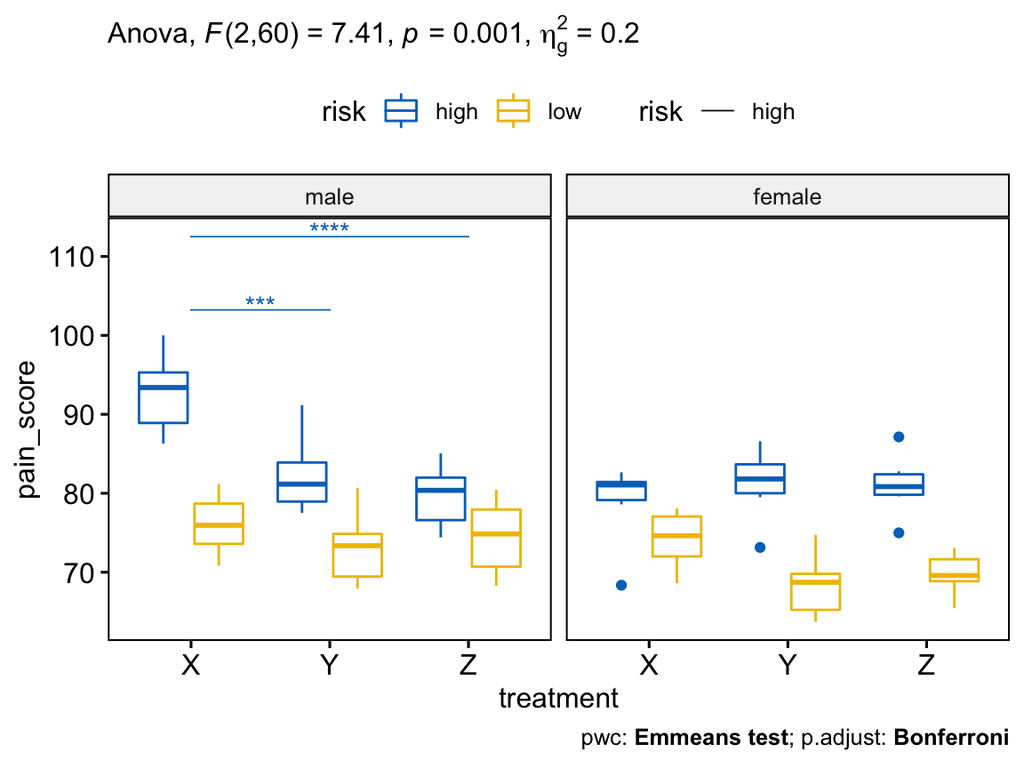

```r
# Visualization: box plots with p-values
pwc <- pwc %>% add_xy_position(x = "treatment")
pwc.filtered <- pwc %>% filter(gender == "male", risk == "high")
bxp +
  stat_pvalue_manual(
    pwc.filtered, color = "risk", linetype = "risk", hide.ns = TRUE,
    tip.length = 0, step.increase = 0.1, step.group.by = "gender"
  ) +
  labs(
    subtitle = get_test_label(res.aov, detailed = TRUE),
    caption = get_pwc_label(pwc)
    )
```

## Summary

This article describes how to compute and interpret ANOVA in R. We also explain the assumptions made by ANOVA tests and provide practical examples of R codes to check whether the test assumptions are met.

## Recommended for you

This section contains best data science and self-development resources to help you on your path.

### Books - Data Science

#### Others

Version: [Français](https://www.datanovia.com/en/fr/lessons/anova-dans-r/)

[(Next Lesson) Repeated Measures ANOVA in R](https://www.datanovia.com/en/lessons/repeated-measures-anova-in-r/)

[Back to Comparing Multiple Means in R](https://www.datanovia.com/en/courses/comparing-multiple-means-in-r/)

### Comments ( 28 )

- Dyaln

  19 May 2020

  First, I LOVE your site – it is incredibly informative and easy to follow. Thanks!!

  I am trying to calculate the simple mean error as in the 2-way anova above, though I would like to do it for many variables at once, so I am trying to use the “map2” function of the purrr package. I have been unsuccessful and cannot figure out how to make this work.

  Here is my data:  
  “` r  
  df # A tibble: 6 x 15  
  #> id edge trt nl lm md c mgg mgcm p sp ap  
  #>  
  #> 1 1 S C 1.80 -1.13 1.75 -0.303 2.94 1.02 1.60 1166. 1.10  
  #> 2 2 S T NA NA NA NA NA NA NA NA NA  
  #> 3 3 D C 1.60 -1.55 1.17 -0.341 1.85 0.787 1.41 663. 0.899  
  #> 4 4 D T 1.34 -2.22 0.962 -0.332 1.65 0.750 0.674 63.6 0.543  
  #> 5 5 S C 1.80 -0.165 2.16 -0.285 3.14 1.09 2.21 496. 1.16  
  #> 6 6 S T 2.14 0.250 2.44 -0.219 3.36 1.16 2.31 911. 1.20  
  #> # … with 3 more variables: la , lacm , lacmd  
  “`

  I’ve successfully run all the two-way anovas I need:  
  “` r  
  models_1 %  
  group_by(edge) %>%  
  map2(ind.trans[4:15], models_1, ~ anova_test(.x, error = .y, type = 3))  
  #> Error in df %>% group_by(edge) %>% map2(ind.trans[4:15], models_1, ~anova_test(.x, : could not find function “%>%”  
  “`

  I receive the following error, even though the number of columns I’m calling and the number of models match:  
  Error: Mapped vectors must have consistent lengths:  
  * `.x` has length 15  
  * `.y` has length 12

  Thanks in advance!  
  Created on 2020-05-19 by the [reprex package](https://reprex.tidyverse.org) (v0.3.0)

  Reply
  - Kassambara

    20 May 2020

    Would you please provide a reproducible example as described at [How to Include Reproducible R Script Examples in Datanovia Comments](https://www.datanovia.com/en/blog/publish-reproducible-examples-from-r-to-datanovia-website/). You will need the pubr R package, which can be installed using devtools::install_github(“kassambara/pubr”)

    Reply
- Gene

  12 Jun 2020

  Hi, About the post hoc test, I would like to know what is the difference between applying a pairwise.t.test and TukeyHSD test if I got a significant result from a Two Way ANOVA?

  Reply
- Liza

  20 Jun 2020

  Thank you! It was very-very helpful!

  Reply
  - Kassambara

    20 Jun 2020

    I appreciate your positive feedback, thank you!

    Reply
- Howard

  16 Jul 2020

  Hi, about your simple main effect and simple two-way interaction, you noted that it needs Bonferroni-adjusted p-value, yet I had noticed that many people do not do the adjustment. Does it necessary?

  Reply
- Howard

  16 Jul 2020

  I like your site. It’s helpful! Thanks.  
  I am doing a three-way ANOVA, and I found that although you noted that it needs a Bonferroni-adjusted alpha level for simple two-way interaction and simple simple main effect in three-way ANOVA, many articles did not do the adjustment. I wonder if it is necessary to do the adjustment, or it’s ok if people don’t do it?

  Reply
- Gabriela vilalba

  22 Jul 2020

  Hello, I have trouble adding the p-value of my post-Hoch test into a box plot. this message appears after running the code of the plot  
  Warning message:  
  Computation failed in `stat_bracket()`:  
  Internal error in `vec_proxy_assign_opts()`: `proxy` of type `double` incompatible with `value` proxy of type `integer`.

  this is my code:

  ```
  water <- read_xls("Water_cont2.xls")
  str(water)

  water <- as.data.frame(water)
  water$treatment <- as.factor(water$treatment)
  levels(water$treatment)


  res.aov % anova_test(Water_Content ~ treatment)
  res.aov

  pwc % tukey_hsd(Water_Content ~ treatment)
  pwc


  pwc % add_xy_position(x = "treatment")
  ggboxplot(water, x = "treatment", y = "Water_Content") +
    stat_pvalue_manual(pwc, hide.ns = TRUE) +
    labs(
      subtitle = get_test_label(res.aov, detailed = TRUE),
      caption = get_pwc_label(pwc)
    )
  ```

  hope you can help me

  thanks

  Reply
  - Kassambara

    22 Jul 2020

    Hi, you have some errors in your code. It should look like as follow:

    ```r
    water <- read_xls("Water_cont2.xls")
    str(water)

    water <- as.data.frame(water)
    water$treatment <- as.factor(water$treatment)
    levels(water$treatment)


    res.aov <-  water %>% anova_test(Water_Content ~ treatment)
    res.aov

    pwc <- water %>% tukey_hsd(Water_Content ~ treatment)
    pwc


    pwc <- pwc %>% add_xy_position(x = "treatment")
    ggboxplot(water, x = "treatment", y = "Water_Content") +
      stat_pvalue_manual(pwc, hide.ns = TRUE) +
      labs(
        subtitle = get_test_label(res.aov, detailed = TRUE),
        caption = get_pwc_label(pwc)
      )
    ```

    Reply
    - Gabriela vilalba

      22 Jul 2020

      Thank you for your help; however, the message is still appearing with your code.

      Warning message:  
      Computation failed in `stat_bracket()`:  
      Internal error in `vec_proxy_assign_opts()`: `proxy` of type `double` incompatible with `value` proxy of type `integer`.

      Reply
      - Kassambara

        23 Jul 2020

        Does this error appears, when using the demo data in this tutorial? Would you please send your data, so that I can check?

        Reply
        - Gabriela vilalba

          23 Jul 2020

          Yes, it also happens with the demo data tutorial, so something must be wrong with my R. Should I download it again?
        - Andrzej

          21 Oct 2020

          Probably the problem is with the operating system. I received the same message on a 64 bit system but the calculations were correct on a 32 bit system. Please check it at your place
        - Kassambara

          21 Oct 2020

          Great that it works! The issue should be something related with your R sessions.
- Belen

  31 Jul 2020

  Hi,

  First of all, thanks for the explanation. It’s very clear and easy to follow. I am concerned about the normality of the residuals assumption. I’m working with a 3×2 factorial design, with repeated measures in one of the two factors. In each of the six combinations, I have 8 -10 measures.

  Do I have to check normality for each combination of factors or is it just one test with all the residuals?

  Thanks very much.

  Reply
- Eiji

  22 Nov 2020

  Hello, thank you so much for this.

  I have a simple question. What does “%>%” mean?

  Thank you

  Reply
  - Alboukadel

    22 Nov 2020

    In R, `%>%` is the pipe operator. It takes the output of one statement and makes it the input of the next statement. When describing it, you can think of it as a “THEN”.

    Take, for example, the following code chunk:

    ```r
    iris %>%
      subset(Sepal.Length > 5) %>%
      print()
    ```

    The code chunk above will translate to something like “you take the Iris data, then you subset the data and then you print the data”.

    Reply
- Masters student

  08 Dec 2020

  I can’t get the following code to work:  
  headache %>%  
  group_by(gender, risk, treatment) %>%  
  shapiro_test(pain_score)

  When I do this with my data I get an error:  
  Error: Problem with `mutate()` input `data`.  
  x Problem with `mutate()` input `data`.  
  x sample size must be between 3 and 5000  
  Input `data` is `map(.data$data, .f, …)`.  
  Input `data` is `map(.data$data, .f, …)`.

  However, I can run the following format:  
  PlantGrowth %>%  
  group_by(group) %>%  
  shapiro_test(weight)

  It appears that it is the group_by function that is failing. When I use either of my variables in the group_by() the shapiro_test() works. However, put together it always fails.

  Any hints?

  Reply
  - Masters student

    08 Dec 2020

    Also, I could imagine the work around: running the shapiro_test() two times, one for each variable.

    e.g. Something like this twice, changing the group_by() variable each time.  
    PlantGrowth %>%  
    group_by(group) %>%  
    shapiro_test(weight)

    Is that appropriate or will that ignore the influence of one variable on each test?

    I also notice my other tibbles are shorter and appear to be only comparing the levels in one variable instead of two levels in both variables. Probably a related problem.

    Any hints?

    Reply
- Gaetan AULLO-RASSER

  21 Jan 2021

  Dear Alboukadel Kassambara,  
  Thanks a lot for your great job, this tutorial about ANOVA is the best i ever seen, and i can’t stop using your R packages.

  I have a question for you or anybody in this kind community : In my data set, i’m doing a 3-way anova, and then pairwise comparison, with bonferroni correction. My concern is about the N chosen by the algorithm to compute the correction. I have a lot of subset (4x3x5), and even if my df is about 100 rows, I think that my pwc (and so my bonferroni correction) should be computed only in each subset (about 5 rows) indepandantly. PWC are OK because of the use of the “group_by” function, but the BF corr. use the overall N instead of the N of the subset (leading to adjusted p-values divided by 100 in spite of 4-5). Am i wrong in my interpretation of the bonferroni correction ? If the idea seems right, does anybody have an idea on how to resolve that ? (i mean, not strictly manually dividing myself all p-values, recreating p.signif symbols, etc).  
  Thanks a lot to everybody !  
  Gaetan.

  Reply
- Johanna L. B.

  26 Feb 2021

  Dear Mr. Kassambara,

  thank you so much for this amazing tutorial! It is the best I ever worked through, made so many things much clearer for me now and really helped me out with my thesis about animal movement data.

  Kind regards

  Reply
- Lindsay

  01 Apr 2021

  Thank you for your detailed descriptions. I have a question about how to switch the comparisons. For example, in the two-way ANOVA example, how would you write the model to compare gender at each education_level? Instead of comparing education_level of each gender as in the example.

  Reply
- Sundy

  12 May 2021

  Hi, thanks for the example. I am trying a 3-way anova. But experiencing with the codes.  
  This command is gicving me an error, and this not able to generate the anova table

  treatment.effect %  
  group_by(gender, risk) %>%  
  anova_test(pain_score ~ treatment, error = model)  
  treatment.effect %>% filter(gender == “male”)

  Error: Input must be a vector, not a object.

  Backtrace:  
  1. treatment.effect %>% filter(gender == “male”)  
  11. vctrs:::stop_scalar_type(…)  
  12. vctrs:::stop_vctrs(msg, “vctrs_error_scalar_type”, actual = x)

  Does anyone know how I can fix that?

  Thks

  Reply
- Lino

  23 Dec 2021

  Hi, thanks for a very helpful article. I have a question.

  When I run the code for three-way anova, the simple-simple main effects with this script:  
  treatment.effect %  
  group_by(gender, risk) %>%  
  anova_test(pain_score ~ treatment, error = model)  
  treatment.effect %>% filter(gender == “male”)

  It always shows this error notification  
  Error: Input must be a vector, not a object.

  Do you know how to fix it?

  Reply
- Guadalupe Rivera

  11 Feb 2022

  Hello,  
  Everything worked so fine until the end with the final plot. The simple bxp is the same as showed but when I add the:

  The simple bxp plots males first then female but after adding the stat_pvalue_manual() and labs() is inverted and pvalue lines are misplaced.

  Reply
- Nb

  25 Feb 2022

  Can anyone explain why I get this error message when I run emmeans-test ;  
  Error in contrast.emmGrid(res.emmeans, by = grouping.vars, method = method, : Nonconforming number of contrast coefficients

  Reply
- Yo

  02 Mar 2022

  Do we not need to check if the data is balanced?

  Reply
- Muhammad Arqam Waheed

  24 Mar 2022

  Dear Alboukadel Kassambara,  
  I have a question, as we do Levene test when the assumption of normality doesn’t meet but in two way ANOVA the normality assumption is getting met in your results, if am not wrong you should have done the Bartlett test and according to the Bartlett p-value comes 0.02 which means it’s violating the assumption of homogeneity but Levene shows 0.06 value which means it meets the assumption, I’m a little bit confused why did you use Levene instead of Bartlett please clarify it.  
  Thanks

  Reply